# `gmc:` Group Mean Center

Generate group summaries and individual deviations within groups

#### Description

Multilevel modelers often need to include predictors like the within-group mean and the deviations of individuals around the mean. This function makes it easy (almost foolproof) to calculate those variables.

#### Usage

```
gmc(dframe, x, by, FUN = mean, suffix = c("_mn", "_dev"),
fulldataframe = TRUE)
```

#### Arguments

- dframe a data frame.
- x Variable names or a vector of variable names. Do NOT supply a variable like dat$x1, do supply a quoted variable name "x1" or a vector c("x1", "x2") by A grouping variable name or a vector of grouping names. Do NOT supply a variable like dat$xfactor, do supply a name “xfactor”, or a vector c(“xfac1”, “xfac2”).
- FUN Defaults to the mean, have not tested alternatives
- suffix The suffixes to be added to column 1 and column 2
- fulldataframe Default TRUE. original data frame is returned with new columna added (which I would call “Stata style”). If FALSE, this will return only newly created columns, the variables with suffix[1] and suffix[2] appended to names. TRUE is easier (maybe safer), but also wastes memory.

#### Examples

```r
## Make a data frame out of the state data collection (see ?state)
data(state)
statenew <- as.data.frame(state.x77)
statenew$region <- state.region
statenew$state <- rownames(statenew)
head(statenew.gmc1 <- gmc(statenew, c("Income", "Population"), by = "region"))
```

```
##            region Population Income Illiteracy Life Exp Murder HS Grad
## Alabama     South       3615   3624        2.1    69.05   15.1    41.3
## Alaska       West        365   6315        1.5    69.31   11.3    66.7
## Arizona      West       2212   4530        1.8    70.55    7.8    58.1
## Arkansas    South       2110   3378        1.9    70.66   10.1    39.9
## California   West      21198   5114        1.1    71.71   10.3    62.6
## Colorado     West       2541   4884        0.7    72.06    6.8    63.9
##            Frost   Area      state Income_mn Population_mn Income_dev
## Alabama       20  50708    Alabama  4011.938      4208.125  -387.9375
## Alaska       152 566432     Alaska  4702.615      2915.308  1612.3846
## Arizona       15 113417    Arizona  4702.615      2915.308  -172.6154
## Arkansas      65  51945   Arkansas  4011.938      4208.125  -633.9375
## California    20 156361 California  4702.615      2915.308   411.3846
## Colorado     166 103766   Colorado  4702.615      2915.308   181.3846
##            Population_dev
## Alabama         -593.1250
## Alaska         -2550.3077
## Arizona         -703.3077
## Arkansas       -2098.1250
## California     18282.6923
## Colorado        -374.3077
```

```r
head(statenew.gmc2 <- gmc(statenew, c("Income", "Population"), by = "region",
fulldataframe = FALSE))
```

```
##            region Income_mn Population_mn Income_dev Population_dev
## Alabama     South  4011.938      4208.125  -387.9375      -593.1250
## Alaska       West  4702.615      2915.308  1612.3846     -2550.3077
## Arizona      West  4702.615      2915.308  -172.6154      -703.3077
## Arkansas    South  4011.938      4208.125  -633.9375     -2098.1250
## California   West  4702.615      2915.308   411.3846     18282.6923
## Colorado     West  4702.615      2915.308   181.3846      -374.3077
```

```r
## Note dangerous step: assumes row alignment is correct.
## return has rownames from original set to identify danger
head(statenew2 <- cbind(statenew, statenew.gmc2))
```

```
##            Population Income Illiteracy Life Exp Murder HS Grad Frost
## Alabama          3615   3624        2.1    69.05   15.1    41.3    20
## Alaska            365   6315        1.5    69.31   11.3    66.7   152
## Arizona          2212   4530        1.8    70.55    7.8    58.1    15
## Arkansas         2110   3378        1.9    70.66   10.1    39.9    65
## California      21198   5114        1.1    71.71   10.3    62.6    20
## Colorado         2541   4884        0.7    72.06    6.8    63.9   166
##              Area region      state region Income_mn Population_mn
## Alabama     50708  South    Alabama  South  4011.938      4208.125
## Alaska     566432   West     Alaska   West  4702.615      2915.308
## Arizona    113417   West    Arizona   West  4702.615      2915.308
## Arkansas    51945  South   Arkansas  South  4011.938      4208.125
## California 156361   West California   West  4702.615      2915.308
## Colorado   103766   West   Colorado   West  4702.615      2915.308
##            Income_dev Population_dev
## Alabama     -387.9375      -593.1250
## Alaska      1612.3846     -2550.3077
## Arizona     -172.6154      -703.3077
## Arkansas    -633.9375     -2098.1250
## California   411.3846     18282.6923
## Colorado     181.3846      -374.3077
```

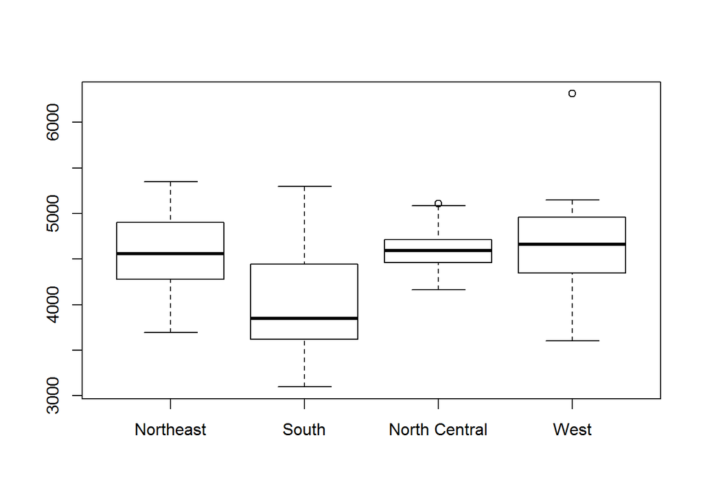

```r
if(!all.equal(rownames(statenew), rownames(statenew.gmc2))){
warning("Data row-alignment probable error")
}
## The following box plots should be identical
boxplot(Income ~ region, statenew.gmc1)
boxplot((Income_mn + Income_dev) ~ region, statenew.gmc1)
```

```r
## Multiple by variables
fakedat <- data.frame(i = 1:200, j = gl(4, 50), k = gl(20, 10),
y1 = rnorm(200), y2 = rnorm(200))
head(gmc(fakedat, "y1", by = "k"), 20)
```

```
##    k  i j          y1         y2      y1_mn     y1_dev
## 1  1  1 1 -1.31130087  0.4177329 0.16776133 -1.4790622
## 2  1  2 1  1.17351514 -1.5782095 0.16776133  1.0057538
## 3  1  3 1 -0.03973001  1.2544372 0.16776133 -0.2074913
## 4  1  4 1 -0.13942843  0.4381934 0.16776133 -0.3071898
## 5  1  5 1  2.58848315  0.7785256 0.16776133  2.4207218
## 6  1  6 1 -1.24805343 -1.4709919 0.16776133 -1.4158148
## 7  1  7 1  0.53858297  1.3574514 0.16776133  0.3708216
## 8  1  8 1  0.14279993  0.4285883 0.16776133 -0.0249614
## 9  1  9 1  1.54466425 -0.7066187 0.16776133  1.3769029
## 10 1 10 1 -1.57191941  1.6882223 0.16776133 -1.7396807
## 11 2 11 1  0.27524143 -0.4031834 0.02786377  0.2473777
## 12 2 12 1  1.08471367  0.3801093 0.02786377  1.0568499
## 13 2 13 1  0.81786230 -1.2901366 0.02786377  0.7899985
## 14 2 14 1  1.21020478 -0.8038402 0.02786377  1.1823410
## 15 2 15 1 -0.28076234  0.9248687 0.02786377 -0.3086261
## 16 2 16 1 -2.22579553  0.1151136 0.02786377 -2.2536593
## 17 2 17 1  0.66245284  0.5206837 0.02786377  0.6345891
## 18 2 18 1  1.95221113 -0.3871425 0.02786377  1.9243474
## 19 2 19 1 -0.70225593 -1.0454663 0.02786377 -0.7301197
## 20 2 20 1 -2.51523468 -0.5484029 0.02786377 -2.5430984
```

```r
head(gmc(fakedat, "y1", by = c("j", "k"), fulldataframe = FALSE), 40)
```

```
##    j k      y1_mn      y1_dev
## 1  1 1 0.16776133 -1.47906220
## 2  1 1 0.16776133  1.00575381
## 3  1 1 0.16776133 -0.20749134
## 4  1 1 0.16776133 -0.30718976
## 5  1 1 0.16776133  2.42072182
## 6  1 1 0.16776133 -1.41581476
## 7  1 1 0.16776133  0.37082164
## 8  1 1 0.16776133 -0.02496140
## 9  1 1 0.16776133  1.37690293
## 10 1 1 0.16776133 -1.73968074
## 11 1 2 0.02786377  0.24737766
## 12 1 2 0.02786377  1.05684990
## 13 1 2 0.02786377  0.78999853
## 14 1 2 0.02786377  1.18234101
```

[output cut: 26 more lines]

```r
head(gmc(fakedat, c("y1", "y2"), by = c("j", "k"), fulldataframe = FALSE))
```

```
##   j k     y1_mn     y2_mn     y1_dev     y2_dev
## 1 1 1 0.1677613 0.2607331 -1.4790622  0.1569998
## 2 1 1 0.1677613 0.2607331  1.0057538 -1.8389426
## 3 1 1 0.1677613 0.2607331 -0.2074913  0.9937041
## 4 1 1 0.1677613 0.2607331 -0.3071898  0.1774603
## 5 1 1 0.1677613 0.2607331  2.4207218  0.5177925
## 6 1 1 0.1677613 0.2607331 -1.4158148 -1.7317250
```

```r
## Check missing value management
fakedat[2, "k"] <- NA
fakedat[4, "j"] <- NA##' head(gmc(fakedat, "y1", by = "k"), 20)
head(gmc(fakedat, "y1", by = c("j", "k"), fulldataframe = FALSE), 40)
```

```
##       j    k      y1_mn      y1_dev
## 1     1    1 0.08044082 -1.39174169
## 2     1 <NA>         NA          NA
## 3     1    1 0.08044082 -0.12017083
## 4  <NA>    1         NA          NA
## 5     1    1 0.08044082  2.50804232
## 6     1    1 0.08044082 -1.32849425
## 7     1    1 0.08044082  0.45814215
## 8     1    1 0.08044082  0.06235911
## 9     1    1 0.08044082  1.46422343
## 10    1    1 0.08044082 -1.65236024
## 11    1    2 0.02786377  0.24737766
## 12    1    2 0.02786377  1.05684990
## 13    1    2 0.02786377  0.78999853
## 14    1    2 0.02786377  1.18234101
```

[output cut: 26 more lines]

36 gmc Details This was originally just for “group mean-centered” data, but now is more general, can accept functions like median to calculate center and then deviations about that center value within the group. Similar to Stata egen, except more versatile and fun! Will create 2 new columns for each variable, with suffixes for the summary and deviations (default suffixes are “_mn" and “_dev“. Rows will match the rows of the original data frame, so it will be easy to merge or cbind them back together. Value Depending on fulldataframe, either a new data frame with center and deviation columns, or or original data frame with”x_mn" and “x_dev” variables appended (Stata style). Author(s) Paul Johnson